# Informe dinámico

Álvaro García Muñoz

2024-04-02

# Introducción

Este documento es un informe dinámico el cuál voy a diseñar usando *toy data* que me servirán para preparar el estudio de un conjunto de datos geneticos sobre enfermedades respiratorias graves, a lo largo de este documento combinaré el uso de python y R para el análisis de los datos.

## Carga de datos

Primero cargaremos los datos en nuestro entorno:

```r
archivo_vcf <-"Data//ALL.chr22.phase3_shapeit2_mvncall_integrated_v5b.20130502.genotypes.vcf"
archivo_cv <-"Data//lists.xlsx"

#snpgdsVCF2GDS(archivo_vcf, "estudio.gds") Este archivo ha de obtenerse antes del informe
covariables <- read.xlsx(archivo_cv)

GDS <- snpgdsOpen("estudio.gds")
```

## Eliminación de LD

```r
snpset <- snpgdsLDpruning(GDS, ld.threshold = 0.2, method = "r")
```

```
## SNP pruning based on LD:
## Excluding 0 SNP on non-autosomes
## Excluding 838,300 SNPs (monomorphic: TRUE, MAF: 0.005, missing rate: 0.05)
##     # of samples: 2,504
##     # of SNPs: 217,154
##     using 1 thread
##     sliding window: 500,000 basepairs, Inf SNPs
##     |LD| threshold: 0.2
##     method: R
## |====================|====================|
## Chromosome 22: 1.23%, 12,940/1,055,454
## 12,940 markers are selected in total.
```

```r
snpset.id <- unlist(unname(snpset))
```

## PCA

Una vez hemos completado el paso del *Linkage disequilibrium*, podemos realizar una primera PCA, en mi caso la voy a realizar de $10$ componentes:

```r
pca <- snpgdsPCA(GDS, snp.id= snpset.id, num.thread = 10)
```

```
## Principal Component Analysis (PCA) on genotypes:
## Excluding 1,042,514 SNPs (non-autosomes or non-selection)
## Excluding 0 SNP (monomorphic: TRUE, MAF: NaN, missing rate: NaN)
##     # of samples: 2,504
##     # of SNPs: 12,940
##     using 10 threads
##     # of principal components: 32
## PCA:    the sum of all selected genotypes (0,1,2) = 60358472
## CPU capabilities: Double-Precision SSE2
## Tue Apr  2 17:38:21 2024    (internal increment: 872)
## [..................................................]  0%, ETC: ---        [==================================================] 100%, completed, 2s
## Tue Apr  2 17:38:23 2024    Begin (eigenvalues and eigenvectors)
## Tue Apr  2 17:38:27 2024    Done.
```

```r
df <- data.frame(sample.id = pca$sample.id,
                 EV1=pca$eigenvect[,1],
                 EV2=pca$eigenvect[,2],
                 EV3=pca$eigenvect[,3],
                 EV4=pca$eigenvect[,4],
                 EV5=pca$eigenvect[,5],
                 EV6=pca$eigenvect[,6],
                 EV7=pca$eigenvect[,7],
                 EV8=pca$eigenvect[,8],
                 EV9=pca$eigenvect[,9],
                 EV10=pca$eigenvect[,10],
                 stringsAsFactors=FALSE)
```

## Visuales

Para terminar con la introducción vamos a proceder a guardar correctamente las componenetes principales como archivos excel:

```r
pca_cv <- data.frame(df, covariables[,-1])
archivo_xlsx <- "Data//PCA10_Covariables.xlsx"
archivo_csv <- "Python//PCA10_Covariables.csv"

write.xlsx(pca_cv,archivo_xlsx)
write.csv(pca_cv, archivo_csv)
```

Una vez hemos guardado los datos y sus covariables en un excel, podemos acceder al programa de python dónde podemos tener una visualización en 3 dimensiones de sus componenetes principales, y a continuación observaremos en el documento una visualización en 2 dimensiones de sus componenetes principales

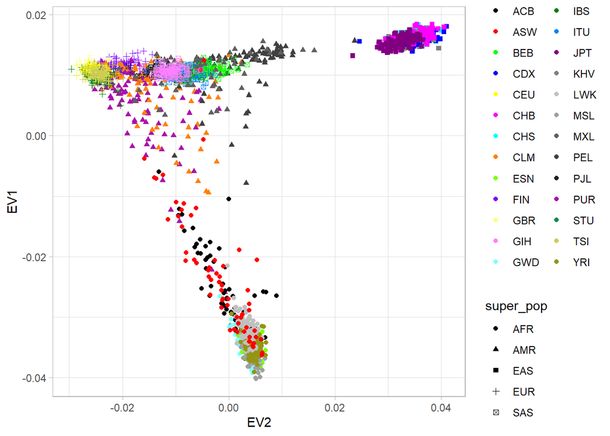

```r
colores <- c("#000000", "#FF0000", "#00FF00", "#0000FF", "#FFFF00", "#FF00FF",
            "#00FFFF", "#FF8000", "#80FF00", "#8000FF", "#FFFF80", "#FF80FF",
            "#80FFFF", "#008000", "#0080FF", "#800080", "#808080", "#C0C0C0",
            "#A0A0A0", "#606060", "#404040", "#202020", "#AA12AA", "#158752",
            "#CCCC56", "#949513")

ggplot(pca_cv, aes(EV2, EV1, color = pop, shape = super_pop)) + geom_point() + scale_color_manual(values=colores) + theme_light()
```

# Clustering clásico

Una vez realizado la PCA vamos a proceder a probar distintas técnicas para el agrupamiento de datos, vamos a empezar por un método clásico.

## K-means

El algoritmo k-means es un método de aprendizaje automático no supervisado que se utiliza para agrupar datos en clusters. El objetivo es dividir los datos en k grupos, de manera que los puntos dentro de cada grupo sean lo más similares posible entre sí y lo más diferentes posible de los puntos de otros grupos.

- 1. Se elige un valor para k, el número de clusters que se desea crear.
- 2. Se seleccionan k puntos al azar de los datos como centroides iniciales.
- 3. Cada punto de datos se asigna al cluster cuyo centroide está más cercano a él.
- 4. Se calculan los nuevos centroides como la media de los puntos de cada cluster.
- 5. Los pasos 3 y 4 se repiten hasta que los centroides no cambien significativamente o se alcance un número máximo de iteraciones.